# Interaction Effects & BH-Corrected Comparisons

- Show All Code
- Hide All Code
- View Source

# Overview

This is the third page of the Dissertation Study 1 workflow. The Profiles page established the four-class positive/negative risk-taking solution, and the Odds Ratios page tested which demographic, peer, and parenting predictors distinguished class membership.

This page extends those findings in two ways:

- **Interaction tests:** the autonomy-supportive parenting (ASP) association is tested for moderation by adolescent biological sex and age. These models ask whether the relationship between ASP and profile membership is stronger, weaker, or directionally different for boys versus girls or across the adolescent age range
- **BH-corrected comparisons:** indicator- and predictor-level pairwise comparisons are displayed together after Benjamini-Hochberg correction so the substantive class differences can be reviewed using a common multiple-testing standard

The interaction models first include the demographic covariates and ASP, then add **ASP × sex** and **ASP × age** terms. As on the Odds Ratios page, model parameters are expressed as odds ratios and pairwise comparisons are corrected before being flagged as significant.

**Analysis Workflow**

**1. Profiles** → **2. Odds Ratios** → **3. Interaction & Comparisons**

Profiles · Odds Ratios · Interaction & Comparisons

Readers who want the descriptive class structure should begin with Profiles; readers who want the primary predictor models should review Odds Ratios before this page.

# Interaction Effects

Tests whether the ASP-predictor association shown in Odds Ratios differs by biological sex or age – i.e., whether autonomy-supportive parenting predicts class membership differently for boys vs. girls, or younger vs. older adolescents, rather than having a uniform effect across the sample. A regression with the four demographic covariates and autonomy suppportive parenting (ASP) was run first, then the two interaction terms (ASP x sex, ASP x age) were added.

Interaction-effect parameters and paired comparisons, by reference class, are read in from the project’s Excel results workbook. Import code is included but not rendered below.

The code for this section is collapsed by default, but can be expanded individually for each section or all together with the toggle on the upper right.

# Results Import

**Raw Results Import**

```r
# Preview raw import
gt(c1_params_raw) |> tab_header(title = "interaction parameters (c1)")
```

interaction parameters (c1)

| predictor_var | predictor_label | Cluster1 | Cluster2 | Cluster3 | Cluster4 | Wald | p-value |
| --- | --- | --- | --- | --- | --- | --- | --- |
| intercept | intercept | 0 | 0.6884 | -0.5823 | -0.8970 | 608.4410 | 1.5e-131 |
| bio_sexD | female | 0 | -1.1301 | -1.1977 | -0.0113 | 243.2900 | 1.8e-52 |
| Zwave1age | average age | 0 | 0.0862 | 0.4401 | 0.3713 | 80.2513 | 2.7e-17 |
| Zpeer_subuse | peer substance use | 0 | 0.4444 | 1.5985 | 1.2723 | 729.4440 | 8.6e-158 |
| pub_timing | pubertal timing | 0 | -0.1360 | 0.1502 | 0.1907 | 51.9033 | 3.1e-11 |
| Zasp | autonomy supportive parenting | 0 | -0.0897 | -0.3401 | -0.2977 | 21.1425 | 9.8e-05 |
| ZaspXbio_sexD | autonomy supportive parenting * sex | 0 | -0.0647 | -0.1235 | -0.0248 | 1.4527 | 6.9e-01 |
| ZaspXZwave1age | autonomy supportive parenting * age | 0 | 0.0590 | 0.0768 | 0.1113 | 4.3237 | 2.3e-01 |

**Clean Results Import**

```r
# Add labels for predictors
pred_labels <- c(
  "bio_sexD"       = "Sex (Female vs. Male)",
  "Zwave1age"    = "Age",
  "Zpeer_subuse" = "Peer Substance Use",
  "pub_timing"   = "Pubertal Timing",
  "Zasp"         = "Autonomy Supportive Parenting",
  "ZaspXbio_sexD" = "Autonomy Supportive Parenting * Child Sex",
  "ZaspXZwave1age" =    "Autonomy Supportive Parenting * Child Age")

# ── Define Parameter-Cleaning Function ────────────────────────────────────────────
tidy_params <- function(raw, cluster_cols) {
  raw %>%
    rename_with(~ "predictor_var", 1) %>%
    rename(omnibus_p = `p-value`) %>%
    pivot_longer(
      cols      = all_of(cluster_cols),
      names_to  = "cluster_raw",
      values_to = "log_odds" ) %>%
    mutate(
      predictor_label = recode(predictor_var, !!!pred_labels),
      log_odds        = as.numeric(log_odds),
      cluster         = recode(cluster_raw,
                          "Cluster1" = "C1", "Cluster2" = "C2",
                          "Cluster3" = "C3", "Cluster4" = "C4"),
      cluster         = factor(cluster, levels = c("C1", "C2", "C3", "C4")),
      OR              = exp(log_odds) ) %>%
    select(predictor_label, predictor_var, cluster, log_odds, OR, omnibus_p)
}

# Apply the cleaning function to the C1-reference parameter sheet
c1_params <- tidy_params(c1_params_raw, c("Cluster1", "Cluster2", "Cluster3", "Cluster4"))
```

## BH Correction on Pairwise Comparisons

```r
# ── Define BH-Correction Function ─────────────────────────────────────────────────
apply_bh_cap <- function(raw) {
  raw %>%
    rename(predictor = Covariate, p_value = `p-value`) %>%
    filter(predictor != "Intercept") %>%
    mutate(
      p_value = as.numeric(p_value),
      p_adj   = p.adjust(p_value, method = "BH"),
      sig     = p_adj < .05 )
}

# ── Apply BH Correction ───────────────────────────────────────────────────────────
c1_pairs <- apply_bh_cap(c1_pairs_raw)
```

**Cleaned Data**

```r
# Display the cleaned interaction-model parameters used for odds-ratio interpretation
gt(c1_params) |> tab_header(title = "data after custom function to clean output")
```

data after custom function to clean output

| predictor_label | predictor_var | cluster | log_odds | OR | omnibus_p |
| --- | --- | --- | --- | --- | --- |
| intercept | intercept | C1 | 0.0000 | 1.0000000 | 1.5e-131 |
| intercept | intercept | C2 | 0.6884 | 1.9905281 | 1.5e-131 |
| intercept | intercept | C3 | -0.5823 | 0.5586121 | 1.5e-131 |
| intercept | intercept | C4 | -0.8970 | 0.4077912 | 1.5e-131 |
| Sex (Female vs. Male) | bio_sexD | C1 | 0.0000 | 1.0000000 | 1.8e-52 |
| Sex (Female vs. Male) | bio_sexD | C2 | -1.1301 | 0.3230010 | 1.8e-52 |
| Sex (Female vs. Male) | bio_sexD | C3 | -1.1977 | 0.3018878 | 1.8e-52 |
| Sex (Female vs. Male) | bio_sexD | C4 | -0.0113 | 0.9887636 | 1.8e-52 |
| Age | Zwave1age | C1 | 0.0000 | 1.0000000 | 2.7e-17 |
| Age | Zwave1age | C2 | 0.0862 | 1.0900243 | 2.7e-17 |
| Age | Zwave1age | C3 | 0.4401 | 1.5528625 | 2.7e-17 |
| Age | Zwave1age | C4 | 0.3713 | 1.4496179 | 2.7e-17 |
| Peer Substance Use | Zpeer_subuse | C1 | 0.0000 | 1.0000000 | 8.6e-158 |
| Peer Substance Use | Zpeer_subuse | C2 | 0.4444 | 1.5595542 | 8.6e-158 |
| Peer Substance Use | Zpeer_subuse | C3 | 1.5985 | 4.9456084 | 8.6e-158 |
| Peer Substance Use | Zpeer_subuse | C4 | 1.2723 | 3.5690519 | 8.6e-158 |
| Pubertal Timing | pub_timing | C1 | 0.0000 | 1.0000000 | 3.1e-11 |
| Pubertal Timing | pub_timing | C2 | -0.1360 | 0.8728426 | 3.1e-11 |
| Pubertal Timing | pub_timing | C3 | 0.1502 | 1.1620666 | 3.1e-11 |
| Pubertal Timing | pub_timing | C4 | 0.1907 | 1.2100964 | 3.1e-11 |
| Autonomy Supportive Parenting | Zasp | C1 | 0.0000 | 1.0000000 | 9.8e-05 |
| Autonomy Supportive Parenting | Zasp | C2 | -0.0897 | 0.9142054 | 9.8e-05 |
| Autonomy Supportive Parenting | Zasp | C3 | -0.3401 | 0.7116991 | 9.8e-05 |
| Autonomy Supportive Parenting | Zasp | C4 | -0.2977 | 0.7425241 | 9.8e-05 |
| Autonomy Supportive Parenting * Child Sex | ZaspXbio_sexD | C1 | 0.0000 | 1.0000000 | 6.9e-01 |
| Autonomy Supportive Parenting * Child Sex | ZaspXbio_sexD | C2 | -0.0647 | 0.9373486 | 6.9e-01 |
| Autonomy Supportive Parenting * Child Sex | ZaspXbio_sexD | C3 | -0.1235 | 0.8838216 | 6.9e-01 |
| Autonomy Supportive Parenting * Child Sex | ZaspXbio_sexD | C4 | -0.0248 | 0.9755050 | 6.9e-01 |
| Autonomy Supportive Parenting * Child Age | ZaspXZwave1age | C1 | 0.0000 | 1.0000000 | 2.3e-01 |
| Autonomy Supportive Parenting * Child Age | ZaspXZwave1age | C2 | 0.0590 | 1.0607752 | 2.3e-01 |
| Autonomy Supportive Parenting * Child Age | ZaspXZwave1age | C3 | 0.0768 | 1.0798261 | 2.3e-01 |
| Autonomy Supportive Parenting * Child Age | ZaspXZwave1age | C4 | 0.1113 | 1.1177302 | 2.3e-01 |

Neither interaction reached significance: ASP x sex, Wald = 1.45, *p* = .69; ASP x age, Wald = 4.32, *p* = .23. This means the ASP-profile association shown on the Odds Ratios page holds equally for males and females, and equally across the adolescent age range studied – higher ASP shifts profile membership toward C1 (High PR-Low NR) to the same degree regardless of the adolescent’s sex or age. This suggests parenting’s role in shaping risk-taking profiles is not confined to a particular developmental window within adolescence, nor does it operate through sex-differentiated pathways (Branje 2018).

## Autonomy-Supportive Parenting × Sex

**C1 graph code**

```r
# ── Select Predictor and Significant Comparisons ──────────────────────────────────
c1_sex <- c1_params %>% filter(predictor_var == "ZaspXbio_sexD")

# ── Identify Reference-Class Differences ──────────────────────────────────────────
ref_sig <- c1_pairs %>%
  filter(predictor == "ZaspXbio_sexD",
         clustera == 1 | clusterb == 1,
         sig == TRUE) %>%
  mutate(other = ifelse(clustera == 1, clusterb, clustera)) %>%
  pull(other)  # Cluster numbers sig different from C1

# ── Identify Additional Pairwise Differences ──────────────────────────────────────
other_sig <- c1_pairs %>%
  filter(predictor == "ZaspXbio_sexD",
         clustera != 1, clusterb != 1,
         sig == TRUE) %>%
  mutate(pair = paste0("C", clustera, " vs. C", clusterb)) %>%
  pull(pair)  # Non-reference sig pairs for caption

# ── Prepare Plot Annotations ──────────────────────────────────────────────────────
c1_sex <- c1_sex %>%
  mutate(
    ast_label = ifelse(as.integer(cluster) %in% ref_sig, "*", ""),
    ast_y     = OR + max(OR) * ast_nudge_pct )

# ── Define Plot Labels ────────────────────────────────────────────────────────────
plot_title   <- "Autonomy Supportive Parenting * Child Sex"
x_label      <- "Reference: C1"
y_label      <- y_lab  # From formatting chunk
fig_caption  <- if (length(other_sig) > 0) {
                  paste0("Additional significant pairwise differences after BH correction (FDR < .05): ",
                         paste(other_sig, collapse = "; "), ".")
              }  else {
                  "No additional pairwise differences were significant after BH correction."
 }

# ── Build Odds-Ratio Figure ───────────────────────────────────────────────────────
p_c1_sex <- ggplot(c1_sex, aes(x = cluster, y = OR, fill = cluster)) +
  geom_col(width = bar_width, alpha = bar_alpha,
            linewidth = bar_outline_lwd) +
  geom_hline(yintercept = 1, color = ref_line_color,
             linewidth = ref_line_lwd, linetype = ref_line_type) +
  geom_text(aes(y = OR, label = round(OR, 2)),
            color = or_label_color, size = or_label_size, vjust = or_label_vjust) +
  geom_text(aes(y = ast_y, label = ast_label),
            size = ast_text_size, vjust = 0.5) +
  scale_fill_manual(values = cluster_colors) +
  scale_y_continuous(expand = expansion(mult = c(0, 0.18)),
                     labels = number_format(accuracy = 0.1)) +
  labs(title = plot_title, x = x_label, y = y_label,
       caption = str_wrap(fig_caption, width = 90)) +
 or_theme + theme(legend.position = "none")
```

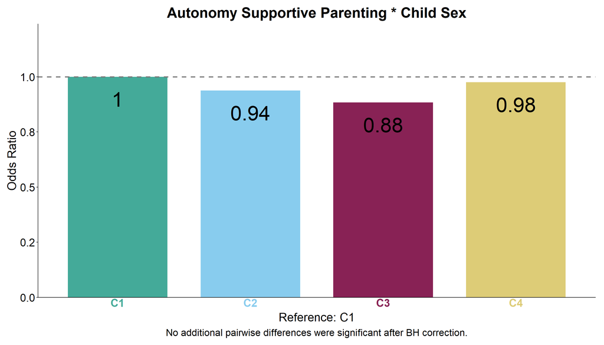

Figure 1

## Autonomy-Supportive Parenting × Age

**C1 graph code**

```r
# ── Select Predictor and Significant Comparisons ──────────────────────────────────
c1_age <- c1_params %>% filter(predictor_var == "ZaspXZwave1age")

# ── Identify Reference-Class Differences ──────────────────────────────────────────
ref_sig <- c1_pairs %>%
  filter(predictor == "ZaspXZwave1age",
         clustera == 1 | clusterb == 1,
         sig == TRUE) %>%
  mutate(other = ifelse(clustera == 1, clusterb, clustera)) %>%
  pull(other)  # Cluster numbers sig different from C1

# ── Identify Additional Pairwise Differences ──────────────────────────────────────
other_sig <- c1_pairs %>%
  filter(predictor == "ZaspXZwave1age",
         clustera != 1, clusterb != 1,
         sig == TRUE) %>%
  mutate(pair = paste0("C", clustera, " vs. C", clusterb)) %>%
  pull(pair)  # Non-reference sig pairs for caption

# ── Prepare Plot Annotations ──────────────────────────────────────────────────────
c1_age <- c1_age %>%
  mutate(
    ast_label = ifelse(as.integer(cluster) %in% ref_sig, "*", ""),
    ast_y     = OR + max(OR) * ast_nudge_pct)

# ── Define Plot Labels ────────────────────────────────────────────────────────────
plot_title   <- "Autonomy Supportive Parenting * Child Age"
x_label      <- "Reference: C1"
y_label      <- y_lab  # From formatting chunk
fig_caption  <- if (length(other_sig) > 0) {
                  paste0("Additional significant pairwise differences after BH correction (FDR < .05): ",
                         paste(other_sig, collapse = "; "), ".")
              }  else {
                  "No additional pairwise differences were significant after BH correction."
 }

# ── Build Odds-Ratio Figure ───────────────────────────────────────────────────────
p_c1_age <- ggplot(c1_age, aes(x = cluster, y = OR, fill = cluster)) +
  geom_col(width = bar_width, alpha = bar_alpha,
            linewidth = bar_outline_lwd) +
  geom_hline(yintercept = 1, color = ref_line_color,
             linewidth = ref_line_lwd, linetype = ref_line_type) +
  geom_text(aes(y = OR, label = round(OR, 2)),
            color = or_label_color, size = or_label_size, vjust = or_label_vjust) +
  geom_text(aes(y = ast_y, label = ast_label),
            size = ast_text_size, vjust = 0.5) +
  scale_fill_manual(values = cluster_colors) +
  scale_y_continuous(expand = expansion(mult = c(0, 0.18)),
                     labels = number_format(accuracy = 0.1)) +
  labs(title = plot_title, x = x_label, y = y_label,
       caption = str_wrap(fig_caption, width = 90)) +
 or_theme + theme(legend.position = "none")
```

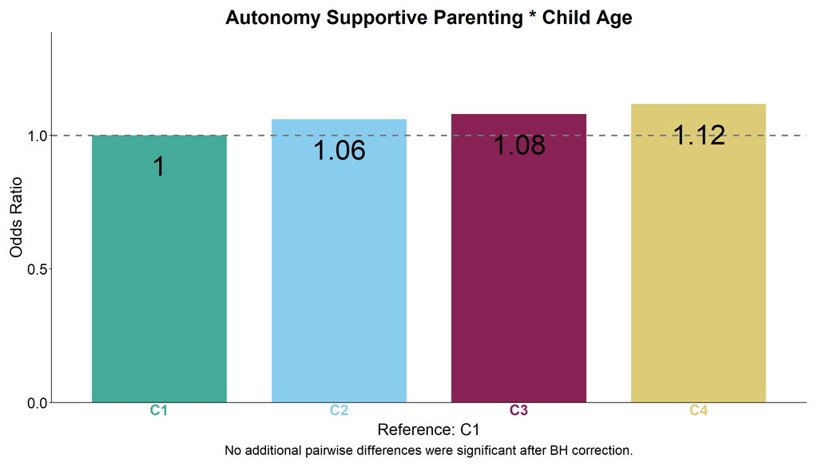

Figure 2

# BH-Corrected Comparisons

Benjamini-Hochberg correction applied to the indicator- and predictor-level pairwise comparisons already introduced on Profiles and Odds Ratios, shown here together for direct comparison. Per Table 3 of the dissertation, negative risk indicators were significant on 57 of 65 possible comparisons and positive risk indicators on 21 of 29, while among predictors, peer substance use was the only one significant on all 6 comparisons – sex was the least discriminating predictor at 4 of 6.

These indicator- and predictor-level pairwise comparisons were already computed against posterior class probabilities from the BCH three-step model estimated in LatentGOLD, which corrects for measurement error in profile assignment (Bolck, Croon, and Hagenaars 2004). What happens on this page is Benjamini-Hochberg correction of those already BCH-corrected comparisons for the multiple-testing problem created by six pairwise class comparisons per indicator/predictor (Benjamini and Hochberg 1995, 2000) – no additional BCH-specific computation happens in this R code. The indicator-level comparisons here are the same `paired comparisons` sheet used on the Profiles page; the predictor-level comparisons are the same `predictors paired comparisons` sheet used on the Odds Ratios page, shown together here for direct comparison.

The code for this section is collapsed by default, but can be expanded individually for each section or all together with the toggle on the upper right.

**Data Import**

```r
# Display the raw BCH-corrected comparison import before cleaning
gt(pred_raw) |> tab_header(title = "predictors paired comparisons")
```

predictors paired comparisons

| covariate | cluster_a | cluster_b | Wald | df | p-value |
| --- | --- | --- | --- | --- | --- |
| Intercept | 1 | 2 | 113.8264 | 1 | 1.4e-26 |
| Intercept | 1 | 3 | 46.6882 | 1 | 8.3e-12 |
| Intercept | 1 | 4 | 95.3149 | 1 | 1.6e-22 |
| Intercept | 2 | 3 | 288.9438 | 1 | 8.4e-65 |
| Intercept | 2 | 4 | 386.3619 | 1 | 5.1e-86 |
| Intercept | 3 | 4 | 8.6115 | 1 | 3.3e-03 |
| bio_sexD | 1 | 2 | 175.5118 | 1 | 4.6e-40 |
| bio_sexD | 1 | 3 | 96.0819 | 1 | 1.1e-22 |
| bio_sexD | 1 | 4 | 0.0514 | 1 | 8.2e-01 |
| bio_sexD | 2 | 3 | 0.0994 | 1 | 7.5e-01 |
| bio_sexD | 2 | 4 | 110.5552 | 1 | 7.4e-26 |
| bio_sexD | 3 | 4 | 80.3489 | 1 | 3.1e-19 |
| Zwave1age | 1 | 2 | 4.7768 | 1 | 2.9e-02 |
| Zwave1age | 1 | 3 | 51.8543 | 1 | 6.0e-13 |
| Zwave1age | 1 | 4 | 48.1391 | 1 | 4.0e-12 |
| Zwave1age | 2 | 3 | 34.5223 | 1 | 4.2e-09 |
| Zwave1age | 2 | 4 | 26.0805 | 1 | 3.3e-07 |
| Zwave1age | 3 | 4 | 1.2073 | 1 | 2.7e-01 |
| Zpeer_subuse | 1 | 2 | 47.9487 | 1 | 4.4e-12 |
| Zpeer_subuse | 1 | 3 | 511.9225 | 1 | 2.4e-113 |
| Zpeer_subuse | 1 | 4 | 397.8266 | 1 | 1.6e-88 |
| Zpeer_subuse | 2 | 3 | 375.2094 | 1 | 1.4e-83 |
| Zpeer_subuse | 2 | 4 | 223.9825 | 1 | 1.2e-50 |
| Zpeer_subuse | 3 | 4 | 30.7176 | 1 | 3.0e-08 |
| pub_timing | 1 | 2 | 9.7248 | 1 | 1.8e-03 |
| pub_timing | 1 | 3 | 6.8767 | 1 | 8.8e-03 |
| pub_timing | 1 | 4 | 12.5589 | 1 | 3.9e-04 |
| pub_timing | 2 | 3 | 28.4378 | 1 | 9.7e-08 |
| pub_timing | 2 | 4 | 39.0790 | 1 | 4.1e-10 |
| pub_timing | 3 | 4 | 0.4318 | 1 | 5.1e-01 |
| Zasp | 1 | 2 | 7.9154 | 1 | 4.9e-03 |
| Zasp | 1 | 3 | 51.0767 | 1 | 8.9e-13 |
| Zasp | 1 | 4 | 30.6871 | 1 | 3.0e-08 |
| Zasp | 2 | 3 | 28.2078 | 1 | 1.1e-07 |
| Zasp | 2 | 4 | 10.5232 | 1 | 1.2e-03 |
| Zasp | 3 | 4 | 3.9439 | 1 | 4.7e-02 |

**Variable Labels**

```r
# Label Indicators
indicator_label_map <- c(
  WSDalc               = "Alcohol Problems",
  cigwhole             = "Cigarette",
  skipschool           = "Skipped school",
  liewhere             = "Lied about whereabouts",
  awayhome             = "Night out(unsanctioned)",
  dare_dum             = "Dangerous dare",
  seatbelt             = "No seatbelt",
  drvdrunk             = "Drove Drunk",
  BC_dum               = "Risky Sex",
  steal12M             = "Theft",
  phyfight             = "Fight",
  WSDsport             = "Sport Teams",
  WSDactivity          = "School Activities",
  avoidproblems        = "Problem Approach",
  disclose             = "Friend Disclosure",
  intitaterelationship = "Initiated Relationship")

# "Negative" = negative risk indicators; "Positive" = positive risk indicators
# (Not currently used in a table below, kept here for future grouping)
indicator_risk_panel <- c(
  WSDalc               = "Negative",
  cigwhole             = "Negative",
  skipschool           = "Negative",
  liewhere             = "Negative",
  awayhome             = "Negative",
  dare_dum             = "Negative",
  seatbelt             = "Negative",
  drvdrunk             = "Negative",
  BC_dum               = "Negative",
  steal12M             = "Negative",
  phyfight             = "Negative",
  WSDsport             = "Positive",
  WSDactivity          = "Positive",
  avoidproblems        = "Positive",
  disclose             = "Positive",
  intitaterelationship = "Positive")
```

## BH Corrections

The indicator- and predictor-level patterns agree in direction: both sets of comparisons separate most sharply along the same alcohol-problem-status divide (C1/C2 vs. C3/C4) that structures the indicator profiles themselves, and peer substance use – the predictor with the most consistent indicator-level analog (negative risk indicators broadly) – is also the most consistently significant predictor. BH correction on top of the BCH-corrected estimates does not change this overall pattern; it affects which specific pairwise comparisons clear the FDR < .05 threshold; see Table 1 and Table 3 for the individual comparisons that did not.

```r
# Clean, BH-correct, and relabel the indicator-level paired comparisons
pairs_6c <- pairs_raw %>%
  filter(Indicator != "Intercept", `p-value` != ".") %>%
  mutate(
    p_value   = as.numeric(`p-value`),
    clustera = as.integer(clustera),
    clusterb = as.integer(clusterb),
    pair      = paste0("C", clustera, " vs. C", clusterb),
    p_adj     = p.adjust(p_value, method = "BH"),
    sig       = p_adj < .05,
    Indicator = recode(Indicator, !!!indicator_label_map))

# Clean, BH-correct, and relabel the predictor-level paired comparisons
pred_pairs <- pred_raw %>%
  filter(covariate != "Intercept", `p-value` != ".") %>%
  mutate(
    p_value   = as.numeric(`p-value`),
    class = as.integer(cluster_a),
    class = as.integer(cluster_b),
    pair      = paste0("C", cluster_a, " vs. C", cluster_b),
    p_adj     = p.adjust(p_value, method = "BH"),
    sig       = p_adj < .05,
    covariate = recode(covariate, !!!pred_labels))
```

**Non-Significant Indicator Comparisons**

```r
# Filter to non-significant indicator comparisons only
nonsig_6c <- pairs_6c %>%
  filter(sig == FALSE) %>%
  select(Indicator, pair, p_value, p_adj) %>%
  mutate(across(c(p_value, p_adj), ~ round(.x, 3))) %>%
  arrange(Indicator, pair)

kable(nonsig_6c,
      col.names = c("Indicator", "Comparison", "Raw p", "BH-adjusted p"),
      caption   = "Non-significant indicator comparisons after Benjamini-Hochberg correction (FDR < .05).")
```

Table 1: Non-significant indicator comparisons after Benjamini-Hochberg correction (FDR < .05).

| Indicator | Comparison | Raw p | BH-adjusted p |
| --- | --- | --- | --- |
| Alcohol Problems | C3 vs. C4 | 0.300 | 0.317 |
| Dangerous dare | C3 vs. C4 | 0.170 | 0.186 |
| Drove Drunk | C3 vs. C4 | 0.085 | 0.099 |
| Fight | C2 vs. C4 | 0.260 | 0.281 |
| Initiated Relationship | C1 vs. C2 | 0.500 | 0.505 |
| Initiated Relationship | C3 vs. C4 | 0.330 | 0.345 |
| Lied about whereabouts | C1 vs. C2 | 0.051 | 0.061 |
| Lied about whereabouts | C3 vs. C4 | 0.290 | 0.310 |
| No seatbelt | C2 vs. C4 | 0.160 | 0.181 |
| Problem Approach | C1 vs. C3 | 0.170 | 0.186 |
| Problem Approach | C1 vs. C4 | 0.380 | 0.388 |
| Problem Approach | C2 vs. C3 | 0.350 | 0.362 |
| Problem Approach | C3 vs. C4 | 0.073 | 0.086 |
| School Activities | C1 vs. C4 | 0.170 | 0.186 |
| Sport Teams | C1 vs. C4 | 0.630 | 0.630 |
| Theft | C3 vs. C4 | 0.150 | 0.172 |

**Significant Indicator Comparisons**

```r
# Filter to significant indicator comparisons only
sig_6c <- pairs_6c %>%
  filter(sig == TRUE) %>%
  select(Indicator, pair, p_value, p_adj) %>%
  mutate(across(c(p_value, p_adj), ~ round(.x, 3))) %>%
  arrange(Indicator, pair)

kable(sig_6c,
      col.names = c("Indicator", "Comparison", "Raw p", "BH-adjusted p"),
      caption   = "Significant indicator comparisons after Benjamini-Hochberg correction (FDR < .05).")
```

Table 2: Significant indicator comparisons after Benjamini-Hochberg correction (FDR < .05).

| Indicator | Comparison | Raw p | BH-adjusted p |
| --- | --- | --- | --- |
| Alcohol Problems | C1 vs. C3 | 0.000 | 0.000 |
| Alcohol Problems | C1 vs. C4 | 0.000 | 0.000 |
| Alcohol Problems | C2 vs. C3 | 0.000 | 0.000 |
| Alcohol Problems | C2 vs. C4 | 0.000 | 0.000 |
| Cigarette | C1 vs. C2 | 0.000 | 0.000 |
| Cigarette | C1 vs. C3 | 0.000 | 0.000 |
| Cigarette | C1 vs. C4 | 0.000 | 0.000 |
| Cigarette | C2 vs. C3 | 0.000 | 0.000 |
| Cigarette | C2 vs. C4 | 0.000 | 0.000 |
| Cigarette | C3 vs. C4 | 0.003 | 0.005 |
| Dangerous dare | C1 vs. C2 | 0.018 | 0.022 |
| Dangerous dare | C1 vs. C3 | 0.000 | 0.000 |
| Dangerous dare | C1 vs. C4 | 0.000 | 0.000 |
| Dangerous dare | C2 vs. C3 | 0.000 | 0.000 |
| Dangerous dare | C2 vs. C4 | 0.000 | 0.000 |
| Drove Drunk | C1 vs. C2 | 0.026 | 0.031 |
| Drove Drunk | C1 vs. C3 | 0.000 | 0.000 |
| Drove Drunk | C1 vs. C4 | 0.000 | 0.000 |
| Drove Drunk | C2 vs. C3 | 0.000 | 0.000 |
| Drove Drunk | C2 vs. C4 | 0.000 | 0.000 |
| Fight | C1 vs. C2 | 0.000 | 0.000 |
| Fight | C1 vs. C3 | 0.000 | 0.000 |
| Fight | C1 vs. C4 | 0.000 | 0.000 |
| Fight | C2 vs. C3 | 0.000 | 0.000 |
| Fight | C3 vs. C4 | 0.000 | 0.000 |
| Friend Disclosure | C1 vs. C2 | 0.000 | 0.000 |
| Friend Disclosure | C1 vs. C3 | 0.012 | 0.015 |
| Friend Disclosure | C1 vs. C4 | 0.000 | 0.000 |
| Friend Disclosure | C2 vs. C3 | 0.000 | 0.000 |
| Friend Disclosure | C2 vs. C4 | 0.000 | 0.000 |
| Friend Disclosure | C3 vs. C4 | 0.000 | 0.000 |
| Initiated Relationship | C1 vs. C3 | 0.000 | 0.000 |
| Initiated Relationship | C1 vs. C4 | 0.000 | 0.000 |
| Initiated Relationship | C2 vs. C3 | 0.000 | 0.000 |
| Initiated Relationship | C2 vs. C4 | 0.000 | 0.000 |
| Lied about whereabouts | C1 vs. C3 | 0.000 | 0.000 |
| Lied about whereabouts | C1 vs. C4 | 0.000 | 0.000 |
| Lied about whereabouts | C2 vs. C3 | 0.000 | 0.000 |
| Lied about whereabouts | C2 vs. C4 | 0.000 | 0.000 |
| Night out(unsanctioned) | C1 vs. C2 | 0.000 | 0.000 |
| Night out(unsanctioned) | C1 vs. C3 | 0.000 | 0.000 |
| Night out(unsanctioned) | C1 vs. C4 | 0.000 | 0.000 |
| Night out(unsanctioned) | C2 vs. C3 | 0.000 | 0.000 |
| Night out(unsanctioned) | C2 vs. C4 | 0.000 | 0.000 |
| Night out(unsanctioned) | C3 vs. C4 | 0.021 | 0.026 |
| No seatbelt | C1 vs. C2 | 0.000 | 0.000 |
| No seatbelt | C1 vs. C3 | 0.000 | 0.000 |
| No seatbelt | C1 vs. C4 | 0.000 | 0.000 |
| No seatbelt | C2 vs. C3 | 0.000 | 0.000 |
| No seatbelt | C3 vs. C4 | 0.000 | 0.000 |
| Problem Approach | C1 vs. C2 | 0.008 | 0.010 |
| Problem Approach | C2 vs. C4 | 0.002 | 0.002 |
| Risky Sex | C1 vs. C2 | 0.000 | 0.000 |
| Risky Sex | C1 vs. C3 | 0.000 | 0.000 |
| Risky Sex | C1 vs. C4 | 0.000 | 0.000 |
| Risky Sex | C2 vs. C3 | 0.000 | 0.000 |
| Risky Sex | C2 vs. C4 | 0.000 | 0.000 |
| Risky Sex | C3 vs. C4 | 0.007 | 0.010 |
| School Activities | C1 vs. C2 | 0.000 | 0.000 |
| School Activities | C1 vs. C3 | 0.000 | 0.000 |
| School Activities | C2 vs. C4 | 0.000 | 0.000 |
| School Activities | C3 vs. C4 | 0.000 | 0.000 |
| Skipped school | C1 vs. C2 | 0.000 | 0.000 |
| Skipped school | C1 vs. C3 | 0.000 | 0.000 |
| Skipped school | C1 vs. C4 | 0.000 | 0.000 |
| Skipped school | C2 vs. C3 | 0.000 | 0.000 |
| Skipped school | C2 vs. C4 | 0.000 | 0.000 |
| Skipped school | C3 vs. C4 | 0.003 | 0.005 |
| Sport Teams | C1 vs. C2 | 0.000 | 0.000 |
| Sport Teams | C1 vs. C3 | 0.000 | 0.000 |
| Sport Teams | C2 vs. C3 | 0.005 | 0.007 |
| Sport Teams | C2 vs. C4 | 0.000 | 0.000 |
| Sport Teams | C3 vs. C4 | 0.000 | 0.000 |
| Theft | C1 vs. C2 | 0.009 | 0.011 |
| Theft | C1 vs. C3 | 0.000 | 0.000 |
| Theft | C1 vs. C4 | 0.000 | 0.000 |
| Theft | C2 vs. C3 | 0.000 | 0.000 |
| Theft | C2 vs. C4 | 0.000 | 0.000 |

**Non-Significant Predictor Comparisons**

```r
# Filter to non-significant predictor comparisons only
nonsig_pred <- pred_pairs %>%
  filter(sig == FALSE) %>%
  select(covariate, pair, p_value, p_adj) %>%
  mutate(across(c(p_value, p_adj), ~ round(.x, 3))) %>%
  arrange(covariate, pair)

kable(nonsig_pred,
      col.names = c("Indicator", "Comparison", "Raw p", "BH-adjusted p"),
      caption   = "Non-significant Predictor comparisons after Benjamini-Hochberg correction (FDR < .05).")
```

Table 3: Non-significant Predictor comparisons after Benjamini-Hochberg correction (FDR < .05).

| Indicator | Comparison | Raw p | BH-adjusted p |
| --- | --- | --- | --- |
| Age | C3 vs. C4 | 0.270 | 0.300 |
| Autonomy Supportive Parenting | C3 vs. C4 | 0.047 | 0.054 |
| Pubertal Timing | C3 vs. C4 | 0.510 | 0.546 |
| Sex (Female vs. Male) | C1 vs. C4 | 0.820 | 0.820 |
| Sex (Female vs. Male) | C2 vs. C3 | 0.750 | 0.776 |

**Significant Predictor Comparisons**

```r
# Filter to significant predictor comparisons only
sig_pred <- pred_pairs %>%
  filter(sig == TRUE) %>%
  select(covariate, pair, p_value, p_adj) %>%
  mutate(across(c(p_value, p_adj), ~ round(.x, 3))) %>%
  arrange(covariate, pair)

kable(sig_pred,
      col.names = c("Indicator", "Comparison", "Raw p", "BH-adjusted p"),
      caption   = "Significant Predictor comparisons after Benjamini-Hochberg correction (FDR < .05).")
```

Table 4: Significant Predictor comparisons after Benjamini-Hochberg correction (FDR < .05).

| Indicator | Comparison | Raw p | BH-adjusted p |
| --- | --- | --- | --- |
| Age | C1 vs. C2 | 0.029 | 0.035 |
| Age | C1 vs. C3 | 0.000 | 0.000 |
| Age | C1 vs. C4 | 0.000 | 0.000 |
| Age | C2 vs. C3 | 0.000 | 0.000 |
| Age | C2 vs. C4 | 0.000 | 0.000 |
| Autonomy Supportive Parenting | C1 vs. C2 | 0.005 | 0.006 |
| Autonomy Supportive Parenting | C1 vs. C3 | 0.000 | 0.000 |
| Autonomy Supportive Parenting | C1 vs. C4 | 0.000 | 0.000 |
| Autonomy Supportive Parenting | C2 vs. C3 | 0.000 | 0.000 |
| Autonomy Supportive Parenting | C2 vs. C4 | 0.001 | 0.002 |
| Peer Substance Use | C1 vs. C2 | 0.000 | 0.000 |
| Peer Substance Use | C1 vs. C3 | 0.000 | 0.000 |
| Peer Substance Use | C1 vs. C4 | 0.000 | 0.000 |
| Peer Substance Use | C2 vs. C3 | 0.000 | 0.000 |
| Peer Substance Use | C2 vs. C4 | 0.000 | 0.000 |
| Peer Substance Use | C3 vs. C4 | 0.000 | 0.000 |
| Pubertal Timing | C1 vs. C2 | 0.002 | 0.002 |
| Pubertal Timing | C1 vs. C3 | 0.009 | 0.011 |
| Pubertal Timing | C1 vs. C4 | 0.000 | 0.001 |
| Pubertal Timing | C2 vs. C3 | 0.000 | 0.000 |
| Pubertal Timing | C2 vs. C4 | 0.000 | 0.000 |
| Sex (Female vs. Male) | C1 vs. C2 | 0.000 | 0.000 |
| Sex (Female vs. Male) | C1 vs. C3 | 0.000 | 0.000 |
| Sex (Female vs. Male) | C2 vs. C4 | 0.000 | 0.000 |
| Sex (Female vs. Male) | C3 vs. C4 | 0.000 | 0.000 |

**Significant Indicator Comparisons by Profile**

```r
# Count how many significant comparisons involve each profile
sig_pairs_6c <- pairs_6c %>% filter(sig == TRUE)

by_cluster_6c <- bind_rows(
  sig_pairs_6c %>% select(cluster = clustera, Indicator),
  sig_pairs_6c %>% select(cluster = clusterb, Indicator)
) %>%
  mutate(cluster = paste0("C", cluster)) %>%
  count(cluster, name = "n_significant") %>%
  arrange(cluster)

kable(by_cluster_6c,
      col.names = c("Profile", "Number of Significant Pairwise Comparisons"),
      caption   = "Count of significant indicator comparisons (BH-corrected, FDR < .05) involving each profile.")
```

Table 5: Count of significant indicator comparisons (BH-corrected, FDR < .05) involving each profile.

| Profile | Number of Significant Pairwise Comparisons |
| --- | --- |
| C1 | 41 |
| C2 | 41 |
| C3 | 38 |
| C4 | 36 |

**Indicator Comparisons by Profile: C1 vs. C2**

```r
# Count significant comparisons specific to the C1 vs. C2 pair
sig_pairs_6c12 <- pairs_6c %>% filter(sig == TRUE & clustera == 1 & clusterb == 2)

sig_pairs_6c12 <- bind_rows(
  sig_pairs_6c12 %>% select(cluster = clustera, Indicator),
  sig_pairs_6c12 %>% select(cluster = clusterb, Indicator)
) %>%
  mutate(cluster = paste0("C", cluster)) %>%
  count(cluster, name = "n_significant") %>%
  arrange(cluster)

kable(sig_pairs_6c12,
      col.names = c("Profile", "Number of Significant Pairwise Comparisons"),
      caption   = "Count of significant indicator comparisons (BH-corrected, FDR < .05) involving each profile.")
# Count non-significant comparisons specific to the C1 vs. C2 pair
nonsig_pairs_6c12 <- pairs_6c %>% filter(sig == FALSE & clustera == 1 & clusterb == 2)

nonsig_pairs_6c12 <- bind_rows(
  nonsig_pairs_6c12 %>% select(cluster = clustera, Indicator),
  nonsig_pairs_6c12 %>% select(cluster = clusterb, Indicator)
) %>%
  mutate(cluster = paste0("C", cluster)) %>%
  count(cluster, name = "n_significant") %>%
  arrange(cluster)

kable(nonsig_pairs_6c12,
      col.names = c("Profile", "Number of Non-Significant Pairwise Comparisons"),
      caption   = "Count of non-significant indicator comparisons (BH-corrected, FDR < .05) involving each profile.")
```

Table 6: Count of non-significant indicator comparisons (BH-corrected, FDR < .05) involving each profile.

| Profile | Number of Significant Pairwise Comparisons |
| --- | --- |
| C1 | 13 |
| C2 | 13 |

| Profile | Number of Non-Significant Pairwise Comparisons |
| --- | --- |
| C1 | 2 |
| C2 | 2 |

**Indicator Comparisons by Profile: C3 vs. C4**

```r
# Count significant comparisons specific to the C3 vs. C4 pair
sig_pairs_6c34 <- pairs_6c %>% filter(sig == TRUE & clustera == 3 & clusterb == 4)

sig_pairs_6c34 <- bind_rows(
  sig_pairs_6c34 %>% select(cluster = clustera, Indicator),
  sig_pairs_6c34 %>% select(cluster = clusterb, Indicator)
) %>%
  mutate(cluster = paste0("C", cluster)) %>%
  count(cluster, name = "n_significant") %>%
  arrange(cluster)

kable(sig_pairs_6c34,
      col.names = c("Profile", "Number of Significant Pairwise Comparisons"),
      caption   = "Count of significant indicator comparisons (BH-corrected, FDR < .05) involving each profile.")
# Count non-significant comparisons specific to the C3 vs. C4 pair
nonsig_pairs_6c34 <- pairs_6c %>% filter(sig == FALSE & clustera == 3 & clusterb == 4)

nonsig_pairs_6c34 <- bind_rows(
  nonsig_pairs_6c34 %>% select(cluster = clustera, Indicator),
  nonsig_pairs_6c34 %>% select(cluster = clusterb, Indicator)
) %>%
  mutate(cluster = paste0("C", cluster)) %>%
  count(cluster, name = "n_significant") %>%
  arrange(cluster)

kable(nonsig_pairs_6c34,
      col.names = c("Profile", "Number of Non-Significant Pairwise Comparisons"),
      caption   = "Count of non-significant indicator comparisons (BH-corrected, FDR < .05) involving each profile.")
```

Table 7: Count of non-significant indicator comparisons (BH-corrected, FDR < .05) involving each profile.

| Profile | Number of Significant Pairwise Comparisons |
| --- | --- |
| C3 | 9 |
| C4 | 9 |

| Profile | Number of Non-Significant Pairwise Comparisons |
| --- | --- |
| C3 | 7 |
| C4 | 7 |

**Significant Demographic Comparisons by Profile**

```r
# Count how many significant predictor comparisons involve each profile
sig_pred <- pred_pairs %>% filter(sig == TRUE)

by_cluster_6pred <- bind_rows(
  sig_pred %>% select(cluster = cluster_a, covariate),
  sig_pred %>% select(cluster = cluster_b, covariate)
) %>%
  mutate(cluster = paste0("C", cluster)) %>%
  count(cluster, name = "n_significant") %>%
  arrange(cluster)

kable(by_cluster_6pred,
      col.names = c("Profile", "Number of Significant Pairwise Comparisons"),
      caption   = "Count of significant Predictor comparisons (BH-corrected, FDR < .05) involving each profile.")
```

Table 8: Count of significant Predictor comparisons (BH-corrected, FDR < .05) involving each profile.

| Profile | Number of Significant Pairwise Comparisons |
| --- | --- |
| C1 | 14 |
| C2 | 14 |
| C3 | 11 |
| C4 | 11 |

**Significant Comparisons by Indicator**

```r
# Total significant vs. non-significant comparisons, by indicator
by_indicator_6c <- pairs_6c %>%
  group_by(Indicator) %>%
  summarise(
    n_total       = n(),
    n_significant = sum(sig),
    n_nonsig      = sum(!sig)
  ) %>%
  arrange(desc(n_significant))

kable(by_indicator_6c,
      col.names = c("Indicator", "Total Comparisons", "Significant", "Non-Significant"),
      caption   = "Count of significant and non-significant pairwise comparisons (BH-corrected, FDR < .05) by indicator.")
```

Table 9: Count of significant and non-significant pairwise comparisons (BH-corrected, FDR < .05) by indicator.

| Indicator | Total Comparisons | Significant | Non-Significant |
| --- | --- | --- | --- |
| Cigarette | 6 | 6 | 0 |
| Friend Disclosure | 6 | 6 | 0 |
| Night out(unsanctioned) | 6 | 6 | 0 |
| Risky Sex | 6 | 6 | 0 |
| Skipped school | 6 | 6 | 0 |
| Dangerous dare | 6 | 5 | 1 |
| Drove Drunk | 6 | 5 | 1 |
| Fight | 6 | 5 | 1 |
| No seatbelt | 6 | 5 | 1 |
| Sport Teams | 6 | 5 | 1 |
| Theft | 6 | 5 | 1 |
| Alcohol Problems | 5 | 4 | 1 |
| Initiated Relationship | 6 | 4 | 2 |
| Lied about whereabouts | 6 | 4 | 2 |
| School Activities | 5 | 4 | 1 |
| Problem Approach | 6 | 2 | 4 |

**Cleaned Data**

```r
# Display the cleaned BCH-corrected comparisons used in the final side-by-side review
gt(pred_pairs) |> tab_header(title = "After: BH-corrected predictor pairwise comparisons")
```

After: BH-corrected predictor pairwise comparisons

| covariate | cluster_a | cluster_b | Wald | df | p-value | p_value | class | pair | p_adj | sig |
| --- | --- | --- | --- | --- | --- | --- | --- | --- | --- | --- |
| Sex (Female vs. Male) | 1 | 2 | 175.5118 | 1 | 4.6e-40 | 4.6e-40 | 2 | C1 vs. C2 | 2.760000e-39 | TRUE |
| Sex (Female vs. Male) | 1 | 3 | 96.0819 | 1 | 1.1e-22 | 1.1e-22 | 3 | C1 vs. C3 | 4.714286e-22 | TRUE |
| Sex (Female vs. Male) | 1 | 4 | 0.0514 | 1 | 8.2e-01 | 8.2e-01 | 4 | C1 vs. C4 | 8.200000e-01 | FALSE |
| Sex (Female vs. Male) | 2 | 3 | 0.0994 | 1 | 7.5e-01 | 7.5e-01 | 3 | C2 vs. C3 | 7.758621e-01 | FALSE |
| Sex (Female vs. Male) | 2 | 4 | 110.5552 | 1 | 7.4e-26 | 7.4e-26 | 4 | C2 vs. C4 | 3.700000e-25 | TRUE |
| Sex (Female vs. Male) | 3 | 4 | 80.3489 | 1 | 3.1e-19 | 3.1e-19 | 4 | C3 vs. C4 | 1.162500e-18 | TRUE |
| Age | 1 | 2 | 4.7768 | 1 | 2.9e-02 | 2.9e-02 | 2 | C1 vs. C2 | 3.480000e-02 | TRUE |
| Age | 1 | 3 | 51.8543 | 1 | 6.0e-13 | 6.0e-13 | 3 | C1 vs. C3 | 2.000000e-12 | TRUE |
| Age | 1 | 4 | 48.1391 | 1 | 4.0e-12 | 4.0e-12 | 4 | C1 vs. C4 | 1.090909e-11 | TRUE |
| Age | 2 | 3 | 34.5223 | 1 | 4.2e-09 | 4.2e-09 | 3 | C2 vs. C3 | 9.000000e-09 | TRUE |
| Age | 2 | 4 | 26.0805 | 1 | 3.3e-07 | 3.3e-07 | 4 | C2 vs. C4 | 5.210526e-07 | TRUE |
| Age | 3 | 4 | 1.2073 | 1 | 2.7e-01 | 2.7e-01 | 4 | C3 vs. C4 | 3.000000e-01 | FALSE |
| Peer Substance Use | 1 | 2 | 47.9487 | 1 | 4.4e-12 | 4.4e-12 | 2 | C1 vs. C2 | 1.100000e-11 | TRUE |
| Peer Substance Use | 1 | 3 | 511.9225 | 1 | 2.4e-113 | 2.4e-113 | 3 | C1 vs. C3 | 7.200000e-112 | TRUE |
| Peer Substance Use | 1 | 4 | 397.8266 | 1 | 1.6e-88 | 1.6e-88 | 4 | C1 vs. C4 | 2.400000e-87 | TRUE |
| Peer Substance Use | 2 | 3 | 375.2094 | 1 | 1.4e-83 | 1.4e-83 | 3 | C2 vs. C3 | 1.400000e-82 | TRUE |
| Peer Substance Use | 2 | 4 | 223.9825 | 1 | 1.2e-50 | 1.2e-50 | 4 | C2 vs. C4 | 9.000000e-50 | TRUE |
| Peer Substance Use | 3 | 4 | 30.7176 | 1 | 3.0e-08 | 3.0e-08 | 4 | C3 vs. C4 | 5.625000e-08 | TRUE |
| Pubertal Timing | 1 | 2 | 9.7248 | 1 | 1.8e-03 | 1.8e-03 | 2 | C1 vs. C2 | 2.454545e-03 | TRUE |
| Pubertal Timing | 1 | 3 | 6.8767 | 1 | 8.8e-03 | 8.8e-03 | 3 | C1 vs. C3 | 1.100000e-02 | TRUE |
| Pubertal Timing | 1 | 4 | 12.5589 | 1 | 3.9e-04 | 3.9e-04 | 4 | C1 vs. C4 | 5.850000e-04 | TRUE |
| Pubertal Timing | 2 | 3 | 28.4378 | 1 | 9.7e-08 | 9.7e-08 | 3 | C2 vs. C3 | 1.711765e-07 | TRUE |
| Pubertal Timing | 2 | 4 | 39.0790 | 1 | 4.1e-10 | 4.1e-10 | 4 | C2 vs. C4 | 9.461538e-10 | TRUE |
| Pubertal Timing | 3 | 4 | 0.4318 | 1 | 5.1e-01 | 5.1e-01 | 4 | C3 vs. C4 | 5.464286e-01 | FALSE |
| Autonomy Supportive Parenting | 1 | 2 | 7.9154 | 1 | 4.9e-03 | 4.9e-03 | 2 | C1 vs. C2 | 6.391304e-03 | TRUE |
| Autonomy Supportive Parenting | 1 | 3 | 51.0767 | 1 | 8.9e-13 | 8.9e-13 | 3 | C1 vs. C3 | 2.670000e-12 | TRUE |
| Autonomy Supportive Parenting | 1 | 4 | 30.6871 | 1 | 3.0e-08 | 3.0e-08 | 4 | C1 vs. C4 | 5.625000e-08 | TRUE |
| Autonomy Supportive Parenting | 2 | 3 | 28.2078 | 1 | 1.1e-07 | 1.1e-07 | 3 | C2 vs. C3 | 1.833333e-07 | TRUE |
| Autonomy Supportive Parenting | 2 | 4 | 10.5232 | 1 | 1.2e-03 | 1.2e-03 | 4 | C2 vs. C4 | 1.714286e-03 | TRUE |
| Autonomy Supportive Parenting | 3 | 4 | 3.9439 | 1 | 4.7e-02 | 4.7e-02 | 4 | C3 vs. C4 | 5.423077e-02 | FALSE |

**Significant Comparisons by Predictor**

```r
# Total significant vs. non-significant comparisons, by predictor
by_indicator_6pred <- pred_pairs %>%
  group_by(covariate) %>%
  summarise(
    n_total       = n(),
    n_significant = sum(sig),
    n_nonsig      = sum(!sig)
  ) %>%
  arrange(desc(n_significant))

kable(by_indicator_6pred,
      col.names = c("Indicator", "Total Comparisons", "Significant", "Non-Significant"),
      caption   = "Count of significant and non-significant pairwise comparisons (BH-corrected, FDR < .05) by Predictor")
```

Table 10: Count of significant and non-significant pairwise comparisons (BH-corrected, FDR < .05) by Predictor

| Indicator | Total Comparisons | Significant | Non-Significant |
| --- | --- | --- | --- |
| Peer Substance Use | 6 | 6 | 0 |
| Age | 6 | 5 | 1 |
| Autonomy Supportive Parenting | 6 | 5 | 1 |
| Pubertal Timing | 6 | 5 | 1 |
| Sex (Female vs. Male) | 6 | 4 | 2 |

Back to top

## References

Benjamini, Yoav, and Yosef Hochberg. 1995. “Controlling the False Discovery Rate: A Practical and Powerful Approach to Multiple Testing.” *Journal of the Royal Statistical Society Series B: Statistical Methodology* 57 (1): 289–300. https://doi.org/10.1111/j.2517-6161.1995.tb02031.x.

———. 2000. “On the Adaptive Control of the False Discovery Rate in Multiple Testing with Independent Statistics.” *Journal of Educational and Behavioral Statistics* 25 (1): 60–83. https://doi.org/10.2307/1165312.

Bolck, Annabel, Marcel Croon, and Jacques Hagenaars. 2004. “Estimating Latent Structure Models with Categorical Variables: One-Step Versus Three-Step Estimators.” *Political Analysis* 12 (1): 3–27. https://www.jstor.org.ezaccess.libraries.psu.edu/stable/25791751.

Branje, Susan. 2018. “Development of ParentAdolescent Relationships: Conflict Interactions as a Mechanism of Change.” *Child Development Perspectives* 12 (3): 171–76. https://doi.org/10.1111/cdep.12278.